# hw02

# This markdown file compile together all the work done and shows overall structure

## Overall Structure

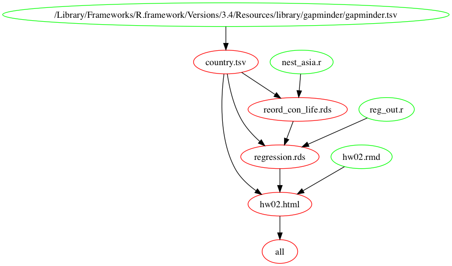

**Initially data was imported from gapminder library in the form of country.tsv**

```r
country_data <- read.delim("country.tsv")
knitr::kable(head(country_data))
```

| country | continent | year | lifeExp | pop | gdpPercap |
| --- | --- | --- | --- | --- | --- |
| Afghanistan | Asia | 1952 | 28.801 | 8425333 | 779.4453 |
| Afghanistan | Asia | 1957 | 30.332 | 9240934 | 820.8530 |
| Afghanistan | Asia | 1962 | 31.997 | 10267083 | 853.1007 |
| Afghanistan | Asia | 1967 | 34.020 | 11537966 | 836.1971 |
| Afghanistan | Asia | 1972 | 36.088 | 13079460 | 739.9811 |
| Afghanistan | Asia | 1977 | 38.438 | 14880372 | 786.1134 |

**Few reference plots were plotted**

- Year vs lifeExp weighted by population for all the contenents

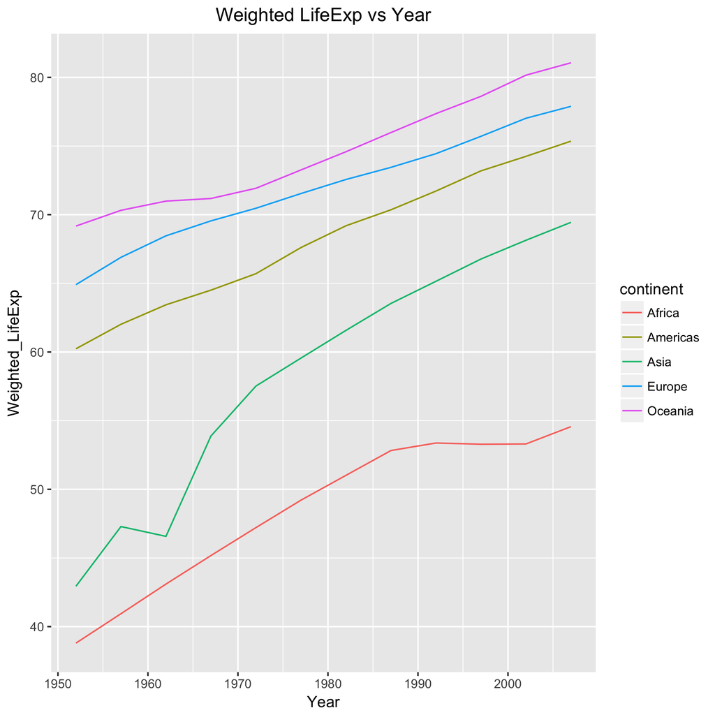

- GDP spread across different continent

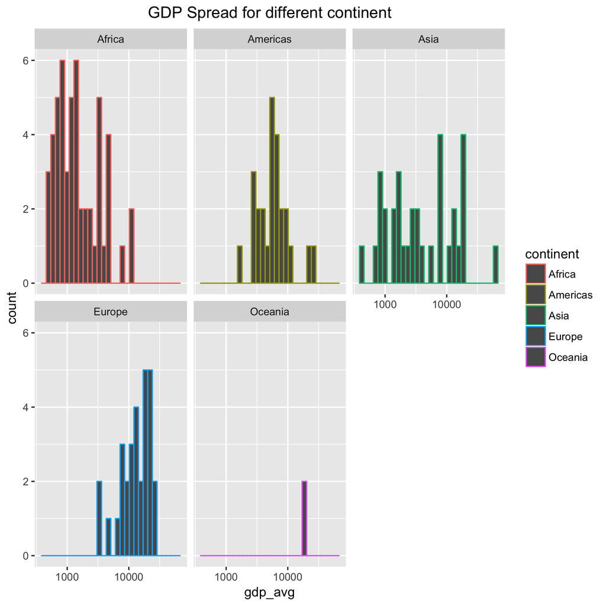

- average pop for each continent before reordering

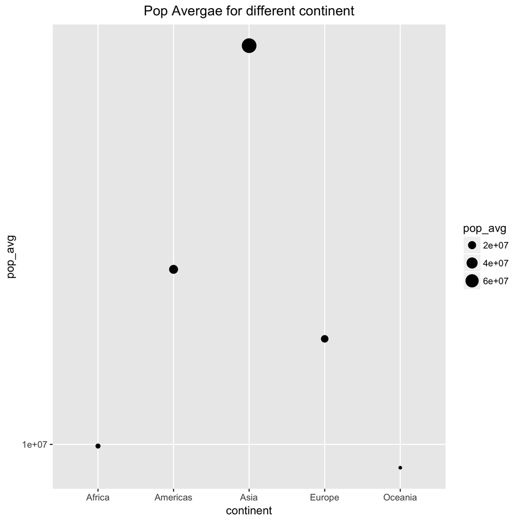

- average pop for each continent after reordering

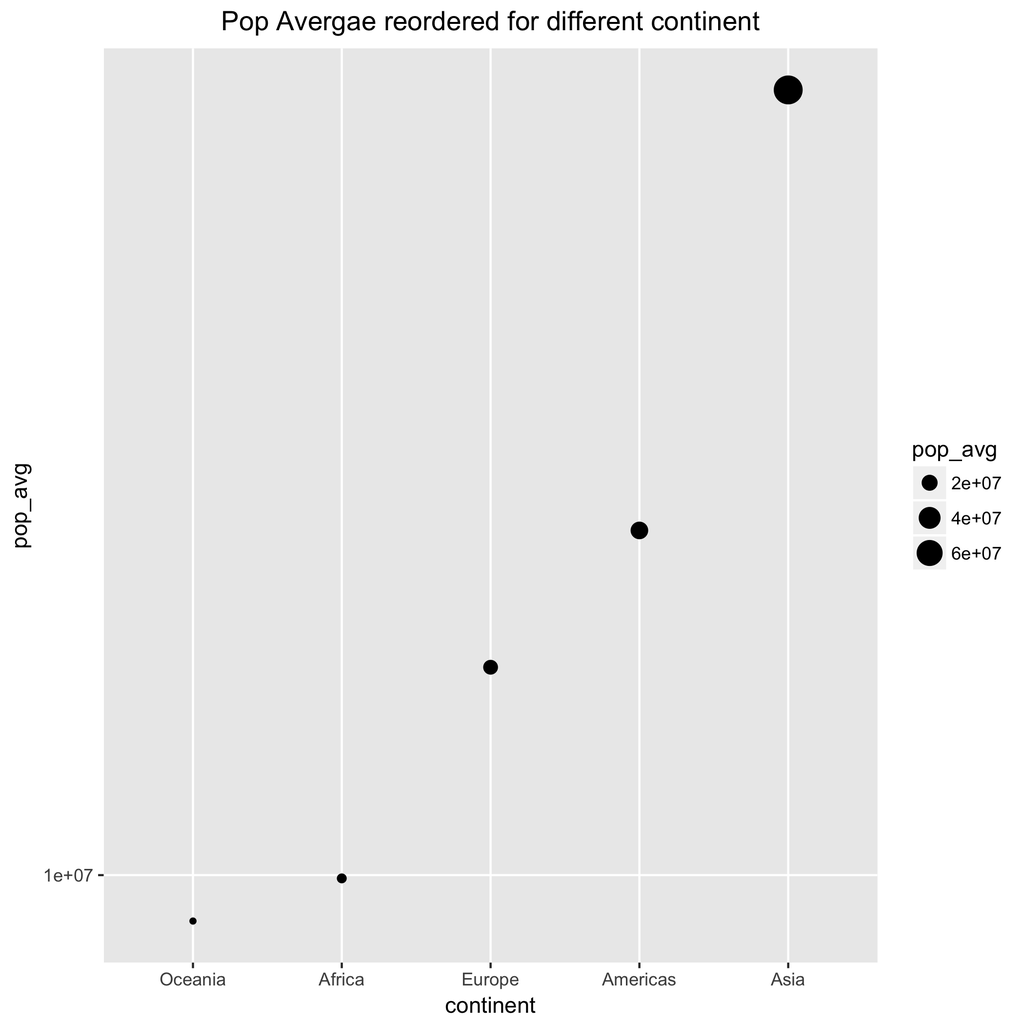

**Continents were reordered based on lifeExp and both plots before and after reordering were plotted and reordered file was saved for further use**

- Median lifeExp for each continent befor reordering

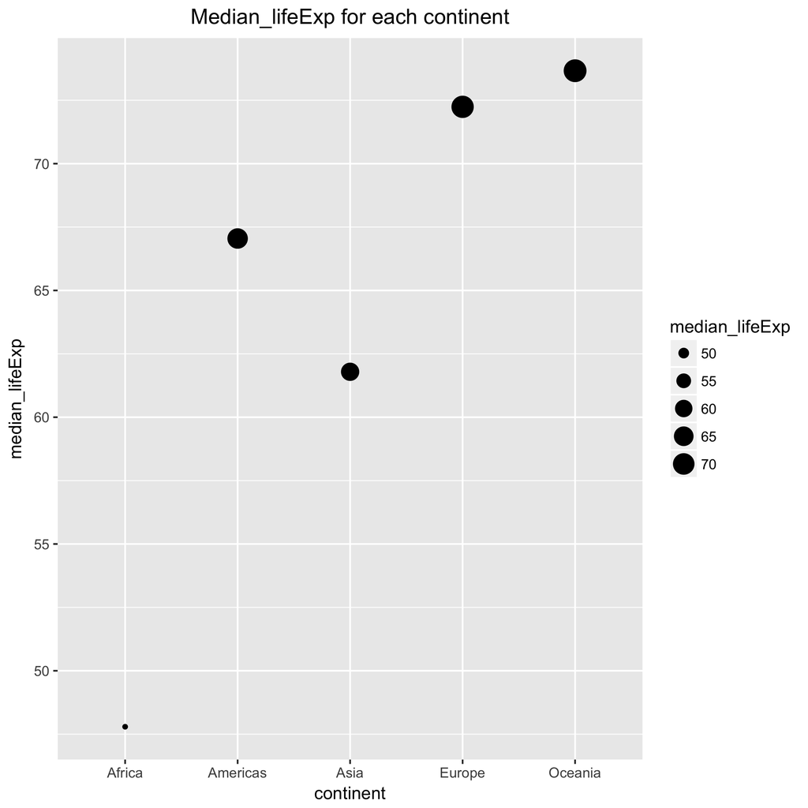

- Median lifeExp for each continent after reordering

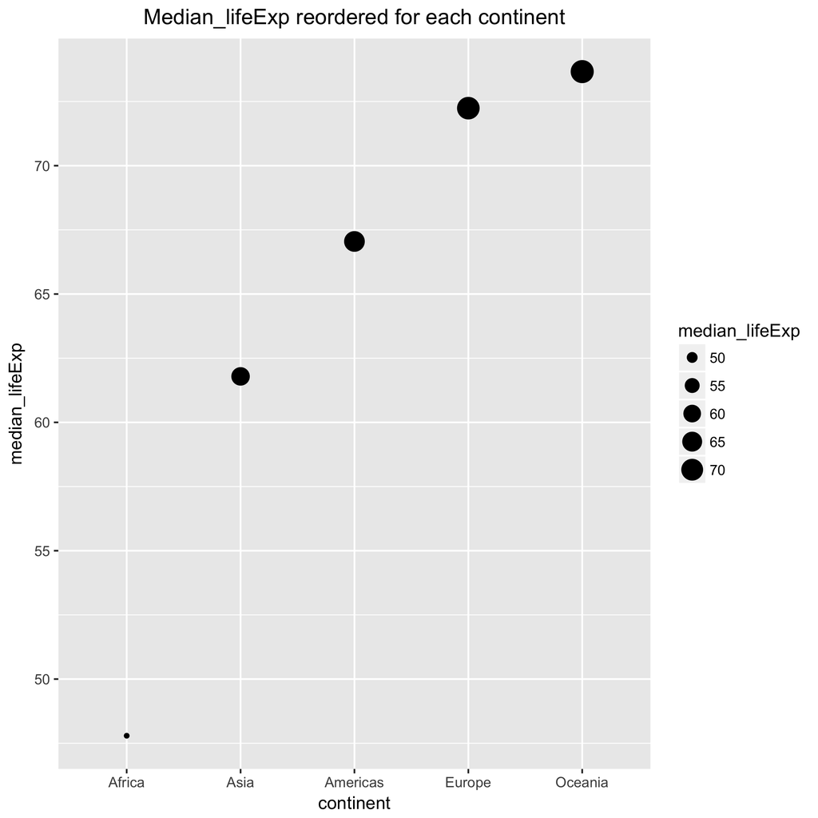

**Fitted a linear model to lifeExp vs year for each country by first nesting the data and then mutating using map and finally unnesting the data**

```r
nest_data <- readRDS("regression.rds")
knitr::kable(head(nest_data))
```

| continent | country | term | estimate | std.error | statistic | p.value |
| --- | --- | --- | --- | --- | --- | --- |
| Asia | Afghanistan | (Intercept) | 29.3566375 | 0.6989813 | 41.99918 | 0.0e+00 |
| Asia | Afghanistan | I(year - 1950) | 0.2753287 | 0.0204509 | 13.46289 | 1.0e-07 |
| Europe | Albania | (Intercept) | 58.5597618 | 1.1335758 | 51.65933 | 0.0e+00 |
| Europe | Albania | I(year - 1950) | 0.3346832 | 0.0331664 | 10.09104 | 1.5e-06 |
| Africa | Algeria | (Intercept) | 42.2364149 | 0.7562690 | 55.84840 | 0.0e+00 |
| Africa | Algeria | I(year - 1950) | 0.5692797 | 0.0221271 | 25.72775 | 0.0e+00 |

**Found the 3 worst countries for Asia and Africa (the rest can be done in same way) by checking the maximum standard error in predicted coefficients for each continent**

- Plot of LifeExp vs years for 3 worst countries for both Asia and Africa

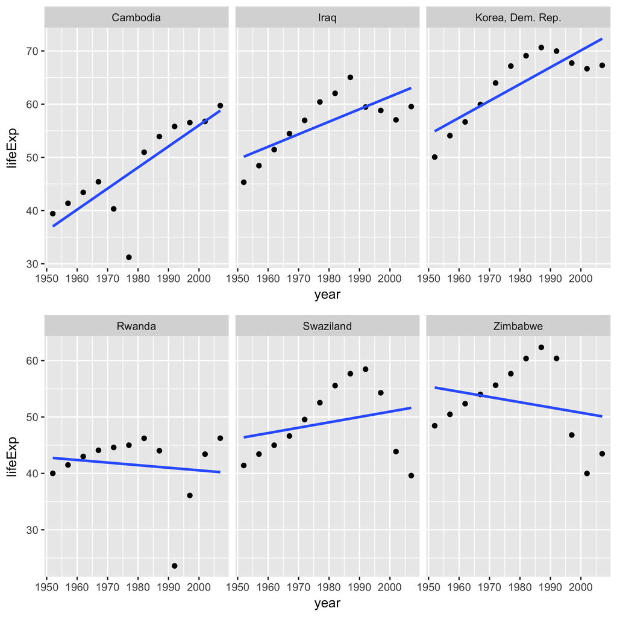

**Saved the data for these countries for both Asia and Africa**